# Practical Machine Learning Project

Eric

Sunday, July 26, 2015

# Background and Sypnosis

Using devices such as Jawbone Up, Nike FuelBand, and Fitbit, it is now possible to collect a large amount of data about personal activity relatively inexpensively. These type of devices are part of the quantified self movement - a group of enthusiasts who take measurements about themselves regularly to improve their health, to find patterns in their behavior, or because they are tech geeks. One thing that people regularly do is quantify how much of a particular activity they do, but they rarely quantify how well they do it.

The goal of this project is thus to use data from accelerometers on the belt, forearm, arm, and dumbell of 6 participants to determine whether they are performing specific exercises correctly. In fact, they were asked to perform barbell lifts correctly and incorrectly in 5 different ways as specified below.

1. Exactly according to the specification - (Class A)
2. Throwing the elbows to the front - (Class B)
3. Lifting the dumbbell only halfway - (Class C)
4. Lowering the dumbbell only halfway - (Class D)
5. Throwing the hips to the front - (Class E)

Two sets (training and testing) of data are provided. Using the training data, we will develop a model that could then be used on the testing data set to determine the class of the excercises being performed by the participants.

**Note:**Additioal information about the data used in this project are available at http://groupware.les.inf.puc-rio.br/har, and comments are inserted throughout the code to explain what is being done.

# Analysis

First, let’s download and load the data.

```r
# Links to download the data
trainLink <- "https://d396qusza40orc.cloudfront.net/predmachlearn/pml-training.csv"
testLink <- "https://d396qusza40orc.cloudfront.net/predmachlearn/pml-testing.csv"

# Downloading the data - Note that you may have to create a "data" folder in your working directory
# if one isn't already there.
#download.file(trainLink, destfile = "./data/train.csv")
#download.file(testLink, destfile = "./data/test.csv")

# Reading the downloaded data - Replacing the missing values with NAs
# A look at the data shows that it contains entry such as "#DIV/0!", thus the following code
trainData <- read.csv("./data/train.csv", na.strings=c("NA","NaN","#DIV/0!", ""), sep = ",", header=TRUE)
testData <- read.csv("./data/test.csv", na.strings=c("NA","NaN","#DIV/0!", ""), sep = ",", header=TRUE)

# Analyzing the data
dim(trainData); dim(testData)
```

```
## [1] 19622   160
```

```
## [1]  20 160
```

```r
head(trainData); names(trainData)
```

[output not shown]

[output cut: 265 more lines]

```
##   [1] "X"                        "user_name"
##   [3] "raw_timestamp_part_1"     "raw_timestamp_part_2"
##   [5] "cvtd_timestamp"           "new_window"
##   [7] "num_window"               "roll_belt"
##   [9] "pitch_belt"               "yaw_belt"
##  [11] "total_accel_belt"         "kurtosis_roll_belt"
##  [13] "kurtosis_picth_belt"      "kurtosis_yaw_belt"
##  [15] "skewness_roll_belt"       "skewness_roll_belt.1"
##  [17] "skewness_yaw_belt"        "max_roll_belt"
##  [19] "max_picth_belt"           "max_yaw_belt"
##  [21] "min_roll_belt"            "min_pitch_belt"
##  [23] "min_yaw_belt"             "amplitude_roll_belt"
##  [25] "amplitude_pitch_belt"     "amplitude_yaw_belt"
##  [27] "var_total_accel_belt"     "avg_roll_belt"
##  [29] "stddev_roll_belt"         "var_roll_belt"
```

[output cut: 65 more lines]

```r
# Restructuring the data - some of the variables do not contribute to the analysis.
trainData <- trainData[, -c(1:7)]
testData <- testData[, -c(1:7)]

# Loading required libraries.
library(caret); library(rpart); library(ggplot2); library(rattle)
library(rpart.plot); library(caTools); library(randomForest)
# Removing more variables that aren't used in the analysis - these variables are NAs or equal to 0.
rmv <- nearZeroVar(trainData)
trainData <- trainData[, -rmv]
testData <- testData[, -rmv]

# A look at the data shows that there are more variables that are simply NAs.
trainData <- trainData[, colSums(is.na(trainData)) == 0]
testData <- testData[, colSums(is.na(testData)) == 0]
```

The restructuring of the data reduces the number of variables/columns from 160 to 53. Further analyses could be done to reduce the number of variables.

Now let’s perform a recursive partitioning for classification.

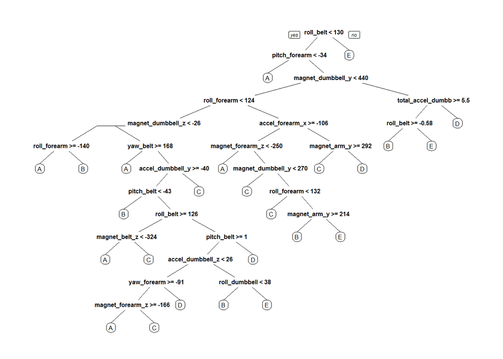

```r
# Setting the seed for reproducibility
set.seed(3333)

# Since the training data is quite large, let's partition it to allow for cross-validation.
split <- sample.split(trainData$classe, SplitRatio = 0.7)
training <- subset(trainData, split==TRUE)
testing <- subset(trainData, split==FALSE)

# Constructing the model
modelfit1 <- rpart(classe ~ ., data=training, , method="class")

# Plotting the tree
prp(modelfit1)
```

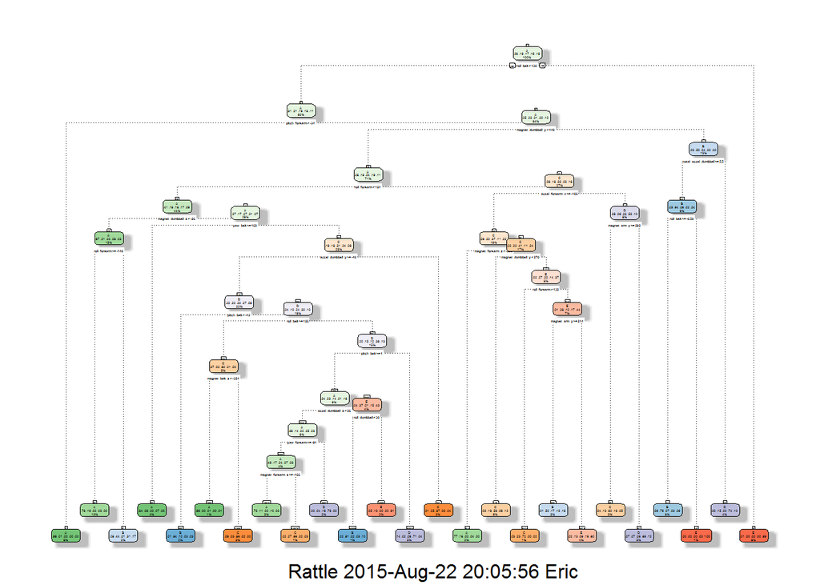

```r
fancyRpartPlot(modelfit1) # To get a better tree but the result is not annotated.
```

```r
# First prediction on the sample test data obtained from the training data
prediction1 <- predict(modelfit1, testing, type="class")

# Testing the results of the first prediction on the sample testing data
confusionMatrix(prediction1, testing$classe)
```

```
## Confusion Matrix and Statistics
##
##           Reference
## Prediction    A    B    C    D    E
##          A 1514  196   20   58   19
##          B   49  662   87   83   86
##          C   45  155  813   76  108
##          D   57   75   89  664   83
##          E    9   51   18   84  786
##
## Overall Statistics
##
##                Accuracy : 0.754
##                  95% CI : (0.7428, 0.765)
##     No Information Rate : 0.2844
##     P-Value [Acc > NIR] : < 2.2e-16
##
##                   Kappa : 0.6882
##  Mcnemar's Test P-Value : < 2.2e-16
##
## Statistics by Class:
##
##                      Class: A Class: B Class: C Class: D Class: E
## Sensitivity            0.9044   0.5812   0.7916   0.6881   0.7264
## Specificity            0.9305   0.9358   0.9210   0.9382   0.9663
## Pos Pred Value         0.8379   0.6846   0.6792   0.6860   0.8291
## Neg Pred Value         0.9608   0.9030   0.9544   0.9388   0.9401
## Prevalence             0.2844   0.1935   0.1745   0.1639   0.1838
## Detection Rate         0.2572   0.1125   0.1381   0.1128   0.1335
## Detection Prevalence   0.3069   0.1643   0.2033   0.1644   0.1610
## Balanced Accuracy      0.9174   0.7585   0.8563   0.8132   0.8464
```

The results of the confusion matrix for the recursive partitioning show the accuracy of this method is **75.4%**

Given that Random Forest is one of the most accurate classifiers, let’s predict the classification model using Random Forrest as follows.

```r
# Performing another fit to see if a better accuracy could be attained.
modelfit2 <- randomForest(classe ~ . , data=training, method="class")

# Second prediction on the sample test data obtained from the training data
prediction2 <- predict(modelfit2, testing, type="class")

# Testing the results of the first prediction on the sample testing data
confusionMatrix(prediction2, testing$classe)
```

```
## Confusion Matrix and Statistics
##
##           Reference
## Prediction    A    B    C    D    E
##          A 1669    4    0    0    0
##          B    4 1131    6    0    0
##          C    0    4 1016   15    0
##          D    0    0    5  949    6
##          E    1    0    0    1 1076
##
## Overall Statistics
##
##                Accuracy : 0.9922
##                  95% CI : (0.9896, 0.9943)
##     No Information Rate : 0.2844
##     P-Value [Acc > NIR] : < 2.2e-16
##
##                   Kappa : 0.9901
##  Mcnemar's Test P-Value : NA
##
## Statistics by Class:
##
##                      Class: A Class: B Class: C Class: D Class: E
## Sensitivity            0.9970   0.9930   0.9893   0.9834   0.9945
## Specificity            0.9991   0.9979   0.9961   0.9978   0.9996
## Pos Pred Value         0.9976   0.9912   0.9816   0.9885   0.9981
## Neg Pred Value         0.9988   0.9983   0.9977   0.9968   0.9988
## Prevalence             0.2844   0.1935   0.1745   0.1639   0.1838
## Detection Rate         0.2835   0.1921   0.1726   0.1612   0.1828
## Detection Prevalence   0.2842   0.1938   0.1758   0.1631   0.1831
## Balanced Accuracy      0.9980   0.9954   0.9927   0.9906   0.9970
```

Based on these results, the Random Forest model is used for prediction on the testing sample data provided.

```r
# Based on the obtained results, Random Forest has a better performance and thus will
# be used on the actual testing data
finalPrediction <- predict(modelfit2, testData, type="class")
finalPrediction
```

```
##  1  2  3  4  5  6  7  8  9 10 11 12 13 14 15 16 17 18 19 20
##  B  A  B  A  A  E  D  B  A  A  B  C  B  A  E  E  A  B  B  B
## Levels: A B C D E
```

The results are then submitted using the provided function (pml_write_files()). After verification, none of the sample data were misclassified.